# Analysis of Maryland Traffic Accidents

## Spring 2024 Data Science Project

by Patrick Gee and Mayukha Suresh

Member 1: Patrick Gee, Contribution: 100%

Member 2: Mayukha Suresh, Contribution: 100%

"We, all team members, agree together that the above information is true, and we are confident about our contributions to this submitted project/final tutorial."

Patrick Gee, Mayukha Suresh

5/7/24

How we each contributed:

A: Project idea: We both explored different project ideas and then agreed on one.

B: Dataset Curation and Preprocessing: We both cleaned our respective datasets, as mentioned below.

C: Data Exploration and Summary Statistics: Patrick looked at temperature, wind speed, visibility; Mayukha looked at wind chill and location data.

D: ML Algorithm Design/Development: We both looked at and worked on both models used.

E: ML Algorithm Training and Test Data Analysis. We both trained the models and then analyzed the results.

F: Visualization, Result Analysis, Conclusion: We both made visualizations and drew conlusions.

G: Final Tutorial Report Creation: We both were involved in creating the final report from start to finish.

**Introduction**

As a soon-to-be commuter college student, the idea of driving to campus and getting into a traffic accident is slightly terrifying, especially as ongoing construction plagues campus with numerous torn up roads and alternative routes. This may seem silly, however, traffic accidents are more common than you may think.

According to the [CDC](https://www.cdc.gov/injury/wisqars/animated-leading-causes.html), from 1981 to 2010, traffic accidents have been the leading cause of unintentional injury deaths in the U.S. From 2011 to 2021, they were still the second leading cause of unintentional injury deaths, only behind poisoning. As a result, traffic accidents are a serious issue and even non-fatal accidents can still cause damage and inconvenience, so any insights about them could be useful.

This motivated us to try to analyze datasets about traffic accidents, which can provide insights into factors contributing to accidents, patterns in accident occurrences, identifying high-risk areas, and ultimately helping to develop strategies for accident prevention and improving road safety.

We initially looked at the dataset "US_Accidents_March23.csv", which we downloaded [here](https://www.kaggle.com/datasets/sobhanmoosavi/us-accidents/data?select=US_Accidents_March23.csv). However, this dataset contains a whopping 7.7 million entries, so we decided to limit our scope. First, we limited the entries to those that had accidents occur in Maryland due to our proximity, so results would be more relevant to us. Secondly, we then limited the number of entries to 100,000 since our initial attempts to load in more data led to technical difficulties and we figured 100,000 entries would be sufficient to analyze.

The final dataset, titled "md_100k.csv" can be found [here](https://drive.google.com/file/d/1EvLvgxfsdcgX9YDj5m6oc4g0xS4yAYib/view?usp=share_link).

**Data Curation**

First, we import some basic libraries, including the pandas library, which allowed us to easily view and manipulate data, and the matplotlib library, which allowed us to easily create plots/graphs to view the data visually. Then we import most of the necessary libraries for later data exploration.

```python
import pandas as pd
import matplotlib.pyplot as plt
import numpy as np
from scipy.stats import chi2_contingency
from scipy.stats import f_oneway
from scipy.stats import kruskal
from sklearn.inspection import DecisionBoundaryDisplay
from sklearn.model_selection import train_test_split
from sklearn.preprocessing import StandardScaler
from sklearn.svm import SVC
```

Then we loaded the data from the csv file into a DataFrame, which is type of a table, and took a look at the first few and last traffic accident entries.

```python
df = pd.read_csv("md_100k.csv")
df
```

|  | ID | Source | Severity | Start_Time | End_Time | Start_Lat | Start_Lng | End_Lat | End_Lng | Distance(mi) | ... | Roundabout | Station | Stop | Traffic_Calming | Traffic_Signal | Turning_Loop | Sunrise_Sunset | Civil_Twilight | Nautical_Twilight | Astronomical_Twilight |
| --- | --- | --- | --- | --- | --- | --- | --- | --- | --- | --- | --- | --- | --- | --- | --- | --- | --- | --- | --- | --- | --- |
| 0 | A-228553 | Source2 | 2 | 2016-11-30 11:58:01 | 2016-11-30 16:57:20 | 39.152046 | -76.645584 | NaN | NaN | 0.010 | ... | False | False | False | False | False | False | Day | Day | Day | Day |
| 1 | A-228554 | Source2 | 3 | 2016-11-30 12:04:03 | 2016-11-30 17:02:36 | 39.152046 | -76.645584 | NaN | NaN | 0.010 | ... | False | False | False | False | False | False | Day | Day | Day | Day |
| 2 | A-228567 | Source2 | 2 | 2016-11-30 16:54:53 | 2016-11-30 17:24:12 | 39.481083 | -76.249626 | NaN | NaN | 0.010 | ... | False | False | False | False | True | False | Night | Day | Day | Day |
| 3 | A-228574 | Source2 | 2 | 2016-11-30 17:33:47 | 2016-11-30 18:01:49 | 39.158756 | -76.718475 | NaN | NaN | 0.010 | ... | False | False | False | False | False | False | Night | Night | Day | Day |
| 4 | A-228580 | Source2 | 2 | 2016-11-30 17:35:33 | 2016-11-30 18:05:10 | 39.636391 | -77.710457 | NaN | NaN | 0.010 | ... | False | False | False | False | True | False | Night | Night | Day | Day |
| ... | ... | ... | ... | ... | ... | ... | ... | ... | ... | ... | ... | ... | ... | ... | ... | ... | ... | ... | ... | ... | ... |
| 99995 | A-6120005 | Source1 | 2 | 2021-05-29 19:04:10 | 2021-05-29 20:20:53 | 39.231995 | -76.506847 | 39.238375 | -76.478327 | 1.589 | ... | False | False | False | False | False | False | Day | Day | Day | Day |
| 99996 | A-6120079 | Source1 | 2 | 2021-06-22 16:25:06 | 2021-06-22 18:52:07 | 38.893801 | -75.815653 | 38.879221 | -75.818603 | 1.020 | ... | False | False | False | False | False | False | Day | Day | Day | Day |
| 99997 | A-6120090 | Source1 | 2 | 2021-07-24 04:17:30 | 2021-07-24 06:20:22 | 38.924614 | -76.853861 | 38.906234 | -76.850121 | 1.286 | ... | False | False | False | False | False | False | Night | Night | Night | Day |
| 99998 | A-6120124 | Source1 | 2 | 2021-11-22 14:45:00 | 2021-11-22 16:47:18 | 39.237561 | -76.466491 | 39.237115 | -76.468010 | 0.087 | ... | False | False | False | False | False | False | Day | Day | Day | Day |
| 99999 | A-6120125 | Source1 | 2 | 2021-09-23 09:51:05 | 2021-09-23 11:17:29 | 39.238265 | -76.464843 | 39.237561 | -76.466491 | 0.101 | ... | False | False | False | False | False | False | Day | Day | Day | Day |

100000 rows × 46 columns

Before conducting any data exploration, we wanted to clean the data a bit by removing duplicates.

```python
df = df.drop_duplicates()
```

Looking at the types of the data, they all seem to be reasonable, so no parsing needs to be done for now.

```python
df.dtypes
```

```
ID                        object
Source                    object
Severity                   int64
Start_Time                object
End_Time                  object
Start_Lat                float64
Start_Lng                float64
End_Lat                  float64
End_Lng                  float64
Distance(mi)             float64
Description               object
Street                    object
City                      object
County                    object
State                     object
Zipcode                   object
Country                   object
Timezone                  object
Airport_Code              object
Weather_Timestamp         object
Temperature(F)           float64
Wind_Chill(F)            float64
Humidity(%)              float64
Pressure(in)             float64
Visibility(mi)           float64
Wind_Direction            object
Wind_Speed(mph)          float64
Precipitation(in)        float64
Weather_Condition         object
Amenity                     bool
Bump                        bool
Crossing                    bool
Give_Way                    bool
Junction                    bool
No_Exit                     bool
Railway                     bool
Roundabout                  bool
Station                     bool
Stop                        bool
Traffic_Calming             bool
Traffic_Signal              bool
Turning_Loop                bool
Sunrise_Sunset            object
Civil_Twilight            object
Nautical_Twilight         object
Astronomical_Twilight     object
dtype: object
```

Now we wanted to explore the potential relationship between temperature and the severity of the accident. We quickly get an overview of the two variables below.

```python
df["Temperature(F)"].describe()
```

```
count    89337.000000
mean        58.388239
std         18.249751
min          1.000000
25%         44.000000
50%         59.000000
75%         73.000000
max        100.900000
Name: Temperature(F), dtype: float64
```

```python
df["Severity"].describe()
```

```
count    100000.000000
mean          2.314540
std           0.569551
min           1.000000
25%           2.000000
50%           2.000000
75%           3.000000
max           4.000000
Name: Severity, dtype: float64
```

We then created a separate dataframe for the temperature and severity. It also seems like some temperature data is missing, so we dropped the rows with missing data.

```python
temp_sev_df = df[["Temperature(F)", "Severity"]].dropna()
temp_sev_df
```

|  | Temperature(F) | Severity |
| --- | --- | --- |
| 0 | 57.9 | 2 |
| 1 | 57.9 | 3 |
| 2 | 59.0 | 2 |
| 3 | 61.0 | 2 |
| 4 | 54.0 | 2 |
| ... | ... | ... |
| 99992 | 81.0 | 2 |
| 99993 | 45.0 | 2 |
| 99994 | 79.0 | 2 |
| 99996 | 68.0 | 2 |
| 99997 | 61.0 | 2 |

89337 rows × 2 columns

Now we can plot the distribution of the temperature at the time of the accidents, grouped by the different severities, of which there are four.

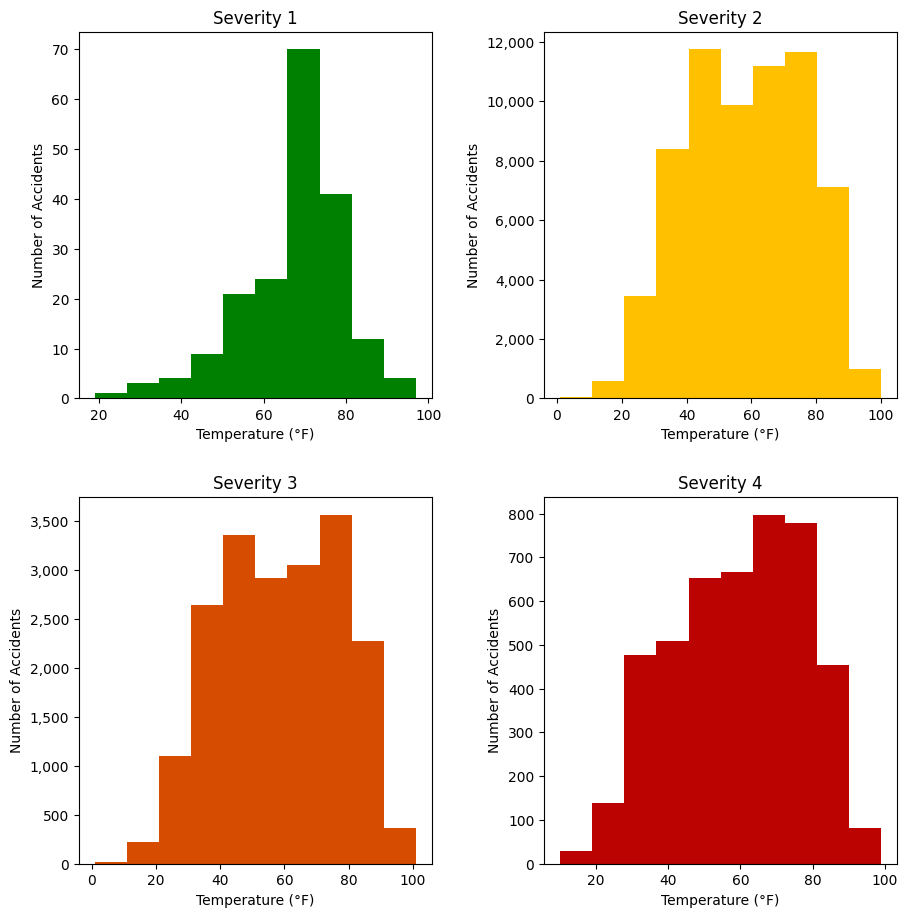

```python
temp_sev_distributions = [temp_sev_df["Temperature(F)"][temp_sev_df["Severity"] == i + 1] for i in range(4)]
severity_colors = ["green", "#FFC000", "#d64c00", "#bb0402"]

fig, axs = plt.subplots(2, 2, figsize = (10, 10))
fig.tight_layout(pad = 5.0)
axs = axs.flatten()

for i in range(4):
  axs[i].hist(temp_sev_distributions[i], color = severity_colors[i])
  axs[i].set_title("Severity " + str(i + 1))
  axs[i].set_xlabel("Temperature (°F)")
  axs[i].set_ylabel("Number of Accidents")
  axs[i].set_yticklabels(['{:,}'.format(int(x)) for x in axs[i].get_yticks().tolist()])
```

We are interested in whether the means of the distributions are actually significantly different from each other, so to get a more definitive view, we can apply an ANOVA test. An ANOVA test is appropriate here since the distributions appear roughly normal and each sample should be mostly independent.

Thus, assuming an alpha value of 0.05,

Null hypothesis: There is no significant difference between the means of the distributions for temperature by severity level

Alternative hypothesis: There is a significant difference between the means of the distributions for temperature by severity level

```python
F, p = f_oneway(temp_sev_distributions[0], temp_sev_distributions[1], temp_sev_distributions[2], temp_sev_distributions[3])
p
```

```
2.6929089410930294e-14
```

Since the obtained p-value is less than 0.05, we reject the null hypothesis and therefore conclude that there is a significant difference between the means of the distributions for temperature by severity level.

Now we wanted to look at the wind speeds during the accidents.

```python
df["Wind_Speed(mph)"].describe()
```

```
count    75221.000000
mean         6.620302
std          5.223967
min          0.000000
25%          3.000000
50%          6.000000
75%          9.000000
max        126.600000
Name: Wind_Speed(mph), dtype: float64
```

From this quick overview, we see that there are probably some outliers since 75% of the accidents that had a recorded wind speed occurred at wind speeds of 9 mph or lower.

After sorting the wind speeds, we got a better look at how many outliers there are and what the associated speeds are.

```python
df["Wind_Speed(mph)"].sort_values(ascending = False).head(10)
```

```
3786     126.6
3782     126.6
3794     126.6
43104    126.6
3784     126.6
22054    117.0
56864     81.0
52941     81.0
53936     81.0
59135     81.0
Name: Wind_Speed(mph), dtype: float64
```

It seems like there are quite a few outliers, in fact, these speeds are as high as those that occur during tornados! To mathematically determine which are actually outliers, one technique is to look at the interquartile range and then find the values that are more than 1.5 times greater than the third quartile.

From the description above we know that the 3rd quartile is 9 and the 1st quartile is 3, so the interquartile range, which is equal to the 3rd quartile minus the first, is 9 - 3 = 6. Thus, any wind speeds greater than 9 + 1.5(6) = 18 mph can be considered outliers.

```python
wind_speed_sev_df = df[["Wind_Speed(mph)", "Severity"]][df["Wind_Speed(mph)"] <= 18].dropna()
wind_speed_sev_df.sort_values("Wind_Speed(mph)", ascending = False).head(10)
```

|  | Wind_Speed(mph) | Severity |
| --- | --- | --- |
| 65521 | 18.0 | 2 |
| 11658 | 18.0 | 3 |
| 62962 | 18.0 | 2 |
| 84078 | 18.0 | 2 |
| 77272 | 18.0 | 2 |
| 73521 | 18.0 | 2 |
| 28636 | 18.0 | 2 |
| 28633 | 18.0 | 3 |
| 22574 | 18.0 | 3 |
| 86705 | 18.0 | 2 |

Now that we have only the non-outlier accidents, we can go ahead and graph the distributions of wind speed by severity level to get some insight into how wind speed affects the severity of the incident.

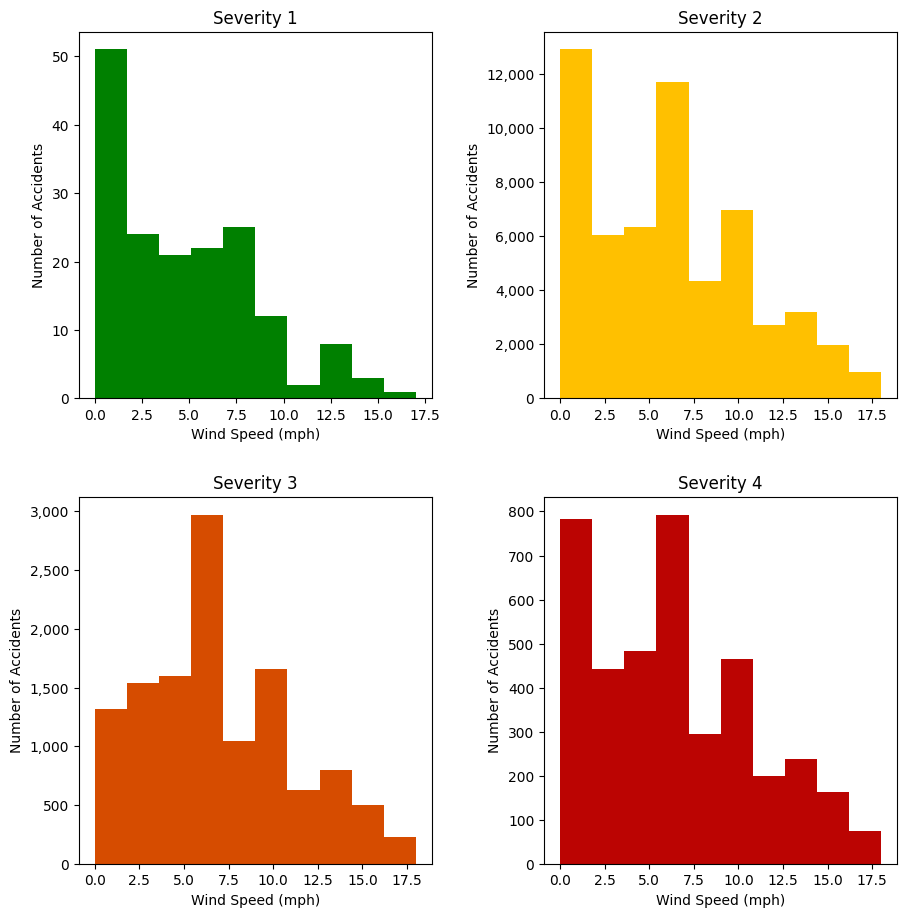

```python
wind_speed_sev_distributions = [wind_speed_sev_df["Wind_Speed(mph)"][wind_speed_sev_df["Severity"] == i + 1] for i in range(4)]

fig, axs = plt.subplots(2, 2, figsize = (10, 10))
fig.tight_layout(pad = 5.0)
axs = axs.flatten()

for i in range(4):
  axs[i].hist(wind_speed_sev_distributions[i], color = severity_colors[i])
  axs[i].set_title("Severity " + str(i + 1))
  axs[i].set_xlabel("Wind Speed (mph)")
  axs[i].set_ylabel("Number of Accidents")
  axs[i].set_yticklabels(['{:,}'.format(int(x)) for x in axs[i].get_yticks().tolist()])
```

It appears that there is a relationship since of the level 1 severity accidents, a smaller proportion of them occurred at higher wind speeds compared to severity levels 2, 3, and 4.

Again, we are interested in whether the means of the distributions are actually significantly different from each other. To more rigorously determine this, we can use the Kruskal-Wallis test, which is similar to the ANOVA test described earlier, but works on data that is not normally distributed, which the wind speed data appears to be.

Using the same alpha value of 0.05 as before:

Null hypothesis: There is no significant difference between the means of the distributions for wind speed by severity level

Alternative hypothesis: There is a significant difference between the means of the distributions for wind speed by severity level

```python
F, p = kruskal(wind_speed_sev_distributions[0], wind_speed_sev_distributions[1], wind_speed_sev_distributions[2], wind_speed_sev_distributions[3])
p
```

```
4.7762255906794065e-74
```

Once again, the p-value is less than 0.05, and so we reject the null hypothesis and therefore can say that there is a significant difference between the means of the distributions for wind speed by severity level.

Now that we've established that there are relationships between the temperature and the severity of the accident and also wind speed and the severity of the accident, we can try to predict the severity of an accident based on the temperature and the wind speed together. To do so, we can use machine learning techniques to help us generate a predictor.

First, we can graph the accidents by their temperature and wind speed and color them accordingly by their severity. To simplify grouping and the overall machine learning process, we can group the accidents into low severity accidents if the severity is 1 or 2 and high severity accidents if the severity is 3 or 4.

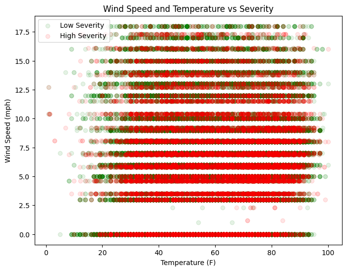

```python
ws_temp_sev_df = df[["Temperature(F)", "Wind_Speed(mph)", "Severity"]][df["Wind_Speed(mph)"] <= 18].dropna()
ws_temp_sev_low_df = ws_temp_sev_df[(ws_temp_sev_df["Severity"] == 1) | (ws_temp_sev_df["Severity"] == 2)]
ws_temp_sev_high_df = ws_temp_sev_df[(ws_temp_sev_df["Severity"] == 3) | (ws_temp_sev_df["Severity"] == 4)]
plt.figure(figsize=(8, 6))
plt.scatter(ws_temp_sev_low_df["Temperature(F)"], ws_temp_sev_low_df["Wind_Speed(mph)"], color = "green", alpha = 0.1)
plt.scatter(ws_temp_sev_high_df["Temperature(F)"], ws_temp_sev_high_df["Wind_Speed(mph)"], color = "red", alpha = 0.1)
plt.title("Wind Speed and Temperature vs Severity")
plt.xlabel("Temperature (F)")
plt.ylabel("Wind Speed (mph)")
plt.legend(["Low Severity", "High Severity"])
```

From the plot, we see that towards the higher and lower ends of the recorded temperatures and at the highest wind speeds there tends be more of the lower severity acccidents. Conversely, we see that there are more of the high severity accidents closer towards the middle of the temperature range and the lower wind speeds.

We can use a support vector machine (SVM) to try to find a hyperplane that can seperate our data so that we can predict whether an accident is low or high severity based on the temperature and wind speed.

First, we create a new dataframe with the severity mapped to 0 or 1 to represent a low or high severity.

```python
svm_ws_temp_sev_df = ws_temp_sev_df
svm_ws_temp_sev_df["Severity"] = svm_ws_temp_sev_df["Severity"].map(lambda x : 0 if x < 3 else 1)
```

Second, we split the data into training datasets and testing datasets and then scale them to avoid biasing the data based on their relative sizes.

```python
scaler = StandardScaler()
X_train, X_test, y_train, y_test = train_test_split(svm_ws_temp_sev_df[["Temperature(F)", "Wind_Speed(mph)"]], svm_ws_temp_sev_df["Severity"], test_size = 0.985)
X_train_scaled = scaler.fit_transform(X_train)
X_test_scaled = scaler.transform(X_test)
```

Third, we can train the model on our training data. However, due to computational limits, the size of the training data must be limited in order to train the model within a reasonable amount of time.

```python
model = SVC(kernel = "poly", degree = 6)
model.fit(X_train_scaled, y_train)
```

```
SVC(degree=6, kernel='poly')
```

After testing several values for the degree of the polynomial, a degree 6 polynomial seems to fit well.

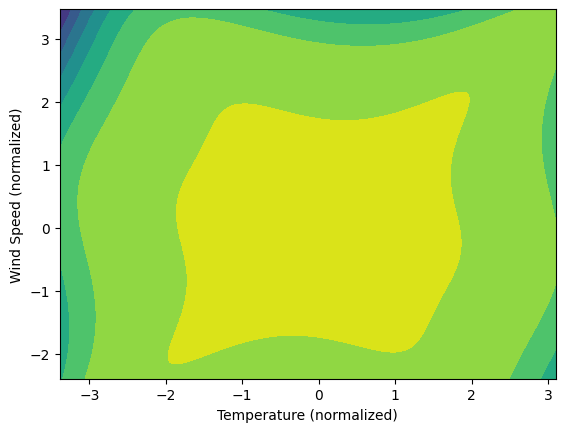

```python
display = DecisionBoundaryDisplay.from_estimator(
    model, X_train_scaled, response_method = "decision_function", xlabel = "Temperature (normalized)", ylabel = "Wind Speed (normalized)")
```

Despite the small proportion of training data used to to train the model, the model does recognize that higher severity accidents tend to be towards the middle of the temperature range and towards the bottom of the wind speed range and that lower severity accidents are in the surrounding areas, as described earlier.

To verify how well the model has actually learned this pattern we can run the model on the testing data and check its accuracy.

```python
predictions_list = model.predict(X_test_scaled).tolist()
y_test_list = y_test.to_list()
num_correct = 0
num_total = len(y_test)
for i in range(num_total):
  if predictions_list[i] == y_test_list[i]:
    num_correct += 1
print(num_correct / num_total)
```

```
0.7792291250471494
```

At about 78% accuracy, the model is not performing well, but is still performing better than we expected.

**Insights**

We now repeat the process to determine if the visibility level during the accident has any significant effect.

```python
vis_df = df[["Visibility(mi)", "Severity"]].dropna()
vis_df
```

|  | Visibility(mi) | Severity |
| --- | --- | --- |
| 0 | 0.5 | 2 |
| 1 | 0.5 | 3 |
| 2 | 0.6 | 2 |
| 3 | 3.0 | 2 |
| 4 | 0.8 | 2 |
| ... | ... | ... |
| 99991 | 10.0 | 2 |
| 99992 | 10.0 | 2 |
| 99994 | 10.0 | 2 |
| 99996 | 7.0 | 2 |
| 99997 | 10.0 | 2 |

80401 rows × 2 columns

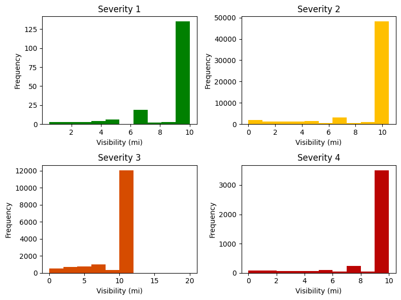

```python
vis_sev_distributions = [vis_df["Visibility(mi)"][vis_df["Severity"] == i + 1] for i in range(4)]

fig, axs = plt.subplots(2, 2, figsize = (8, 6))
axs = axs.flatten()

for i in range(4):
  axs[i].hist(vis_sev_distributions[i], color = severity_colors[i])
  axs[i].set_title(f'Severity {i + 1}')
  axs[i].set_xlabel('Visibility (mi)')
  axs[i].set_ylabel('Frequency')
plt.tight_layout()
plt.show()
```

It is interesting to observe that the mode visibility for the second most severe accidents (3) is 11 while mode of all other severity is lower. Also interesting that the visibility for the most and least severe accidents is the same (9). It is also interesting that the highest visibility for an accident is of severity 3.

Running the chi-squared test on this would be interesting to see if the visibility has any bearing on the severity of the crash.

Null hypothesis: There is no significant difference between the visibility means for each severity level.

Alternative hypothesis: There is a significant difference between the visibility means for each severity level.

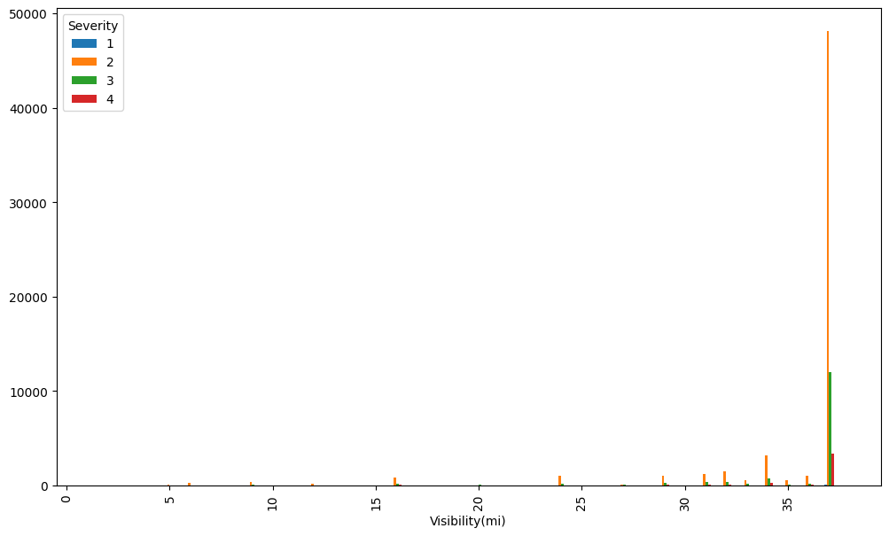

```
2.699494189736634e-80
```

```python
contingency_table = pd.crosstab(vis_df['Visibility(mi)'], vis_df['Severity'])
ax = contingency_table.plot(kind='bar', figsize=(12, 7))
plt.xscale('linear')
plt.show()
chi2_contingency(contingency_table).pvalue
```

Since the p-value is significantly less that 0.05, we can conclude that there is a significance correlation between visibility and severity of an accident.

We also wanted to explore if accidents were significantly more prevalent in a particular county.

Graph of the number of accidents by county.

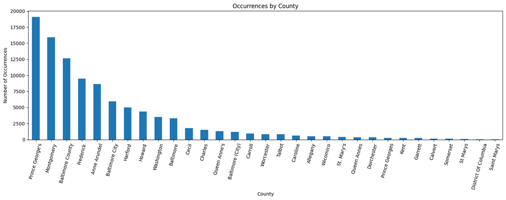

```python
county_counts = df['County'].value_counts()

# Plotting
plt.figure(figsize=(15, 6))
county_counts.plot(kind='bar')
plt.title('Occurrences by County')
plt.ylabel('Number of Occurrences')
plt.xticks(rotation=75)
plt.tight_layout()
plt.show()
```

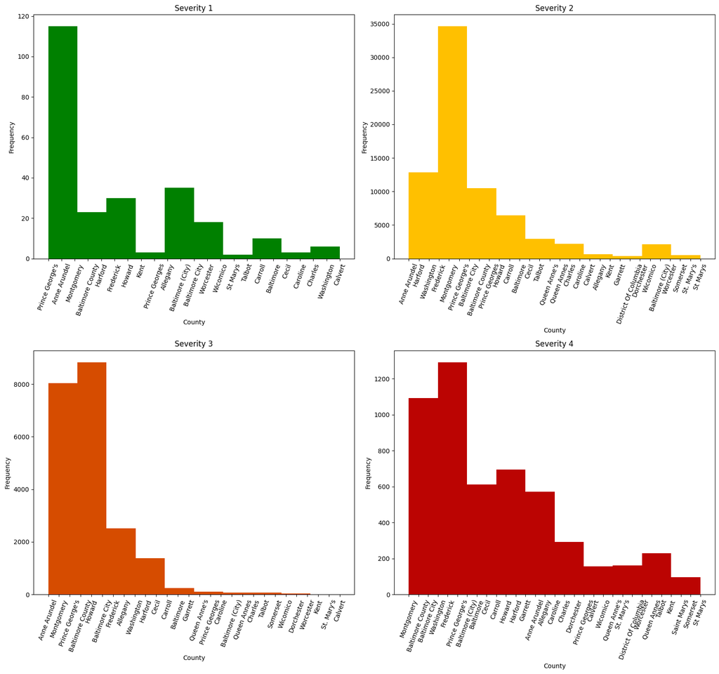

```python
county_sev_df = df[["County", "Severity"]].dropna()
county_sev_distributions = [county_sev_df["County"][county_sev_df["Severity"] == i + 1] for i in range(4)]

fig, axs = plt.subplots(2, 2, figsize = (16, 15))
axs = axs.flatten()

for i in range(4):
  axs[i].hist(county_sev_distributions[i], color = severity_colors[i])
  axs[i].set_title(f'Severity {i + 1}')
  axs[i].set_xlabel('County')
  axs[i].set_ylabel('Frequency')
  axs[i].tick_params(axis='x', rotation=70)

plt.tight_layout()
plt.show()
```

Null hypothesis: There is no significant difference between the county means for each severity level.

Alternative hypothesis: There is a significant difference between the county means for each severity level.

We can ran the chi-squared test to see if there is a significant correlation between the street and severity. This will essentially give us a sense of recognizing if the location of the accident has any bearing on the severity of the accident. This can then be translated to the latitude and longitude being used in our prediction model to predict the severity.

```python
street_mapping = ement_to_integer_mapping = {element: index for index, element in enumerate(df['Street'].unique().tolist())}
street_contingency_table = pd.crosstab(df['Street'].map(street_mapping), df['Severity'])
chi2_contingency(street_contingency_table).pvalue

county_mapping = ement_to_integer_mapping = {element: index for index, element in enumerate(df['Street'].unique().tolist())}
county_contingency_table = pd.crosstab(df['Street'].map(county_mapping), df['Severity'])
chi2_contingency(county_contingency_table).pvalue
```

```
0.0
```

It would be useful to track the relation between the severity and wind chill to see this aspect of the weather impacts the severity. This will be useful when we train out model to predict severity of an accident.

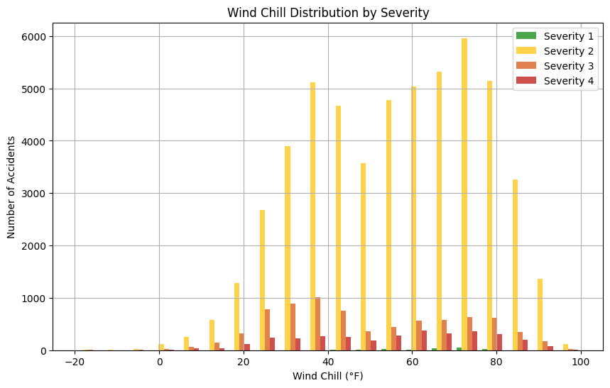

```python
# Combine data from all severity levels into one list
combined_data = [df["Wind_Chill(F)"][df["Severity"] == i + 1] for i in range(4)]

# Define colors for each severity level
severity_colors = ["green", "#FFC000", "#d64c00", "#bb0402"]

# Create a single histogram with different colors
plt.figure(figsize=(10, 6))
plt.hist(combined_data, bins=20, color=severity_colors, alpha=0.7, label=['Severity 1', 'Severity 2', 'Severity 3', 'Severity 4'])
plt.title("Wind Chill Distribution by Severity")
plt.xlabel("Wind Chill (°F)")
plt.ylabel("Number of Accidents")
plt.legend()
plt.grid(True)
plt.show()
```

Visually, it looks like the distribution is bimodal, peaking at around 35F and 75F. We are interested in whether the means of the distributions are actually significantly different from each other, so to get a more definitive view, we can apply an ANOVA test again. An ANOVA test is appropriate here since the distributions appear roughly normal and each sample should be mostly independent. Thus, assuming an alpha value of 0.05, Null hypothesis: There is no significant difference between the means of the distributions for each severity level Alternative hypothesis: There is a significant difference between the means of the distributions for each severity level.

```python
windchill_df = df[["Wind_Chill(F)", "Severity"]].dropna()
windchill_sev_distributions = [windchill_df["Wind_Chill(F)"][windchill_df["Severity"] == i + 1] for i in range(4)]
F, p = f_oneway(windchill_sev_distributions[0], windchill_sev_distributions[1], windchill_sev_distributions[2], windchill_sev_distributions[3])
p
```

```
3.533795809068153e-164
```

Since the obtained p-value is less than 0.05, we reject the null hypothesis and therefore conclude that there is a significant difference between the means of the distributions for each severity level of wind chill.

Moving on, we will now track the relation between the severity and humidity to see this aspect of the weather impacts the severity.

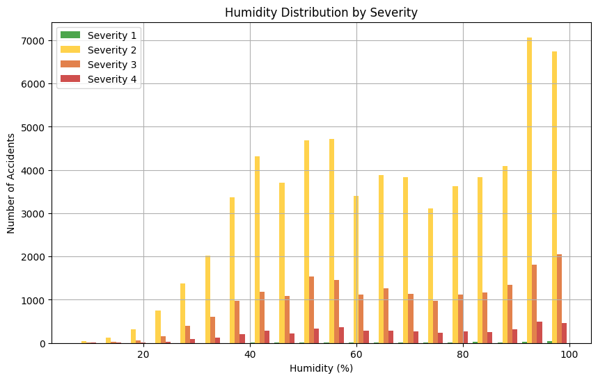

```python
# Combine data from all severity levels into one list
combined_data = [df["Humidity(%)"][df["Severity"] == i + 1] for i in range(4)]

# Define colors for each severity level
severity_colors = ["green", "#FFC000", "#d64c00", "#bb0402"]

# Create a single histogram with different colors
plt.figure(figsize=(10, 6))
plt.hist(combined_data, bins=20, color=severity_colors, alpha=0.7, label=['Severity 1', 'Severity 2', 'Severity 3', 'Severity 4'])
plt.title("Humidity Distribution by Severity")
plt.xlabel("Humidity (%)")
plt.ylabel("Number of Accidents")
plt.legend()
plt.grid(True)
plt.show()
```

Visually, it looks like the distribution is bimodal, peaking at around 55% and 95%. We are interested in whether the means of the distributions are actually significantly different from each other, so to get a more definitive view, we can apply an ANOVA test again. An ANOVA test is appropriate here since the distributions appear roughly normal and each sample should be mostly independent.

Thus, assuming an alpha value of 0.05,

Null hypothesis: There is no significant difference between the means of the distributions for each severity level

Alternative hypothesis: There is a significant difference between the means of the distributions for each severity level.

```python
hum_df = df[["Humidity(%)", "Severity"]].dropna()
hum_sev_distributions = [hum_df["Humidity(%)"][hum_df["Severity"] == i + 1] for i in range(4)]
F, p = f_oneway(hum_sev_distributions[0], hum_sev_distributions[1], hum_sev_distributions[2], hum_sev_distributions[3])
p
```

```
1.0150220493533608e-09
```

Since the obtained p-value is less than 0.05, we reject the null hypothesis and therefore conclude that there is a significant difference between the means of the distributions for each severity level of humidity.

Lastly, we will now track the relation between the severity and pressure to see this aspect of the weather impacts the severity.

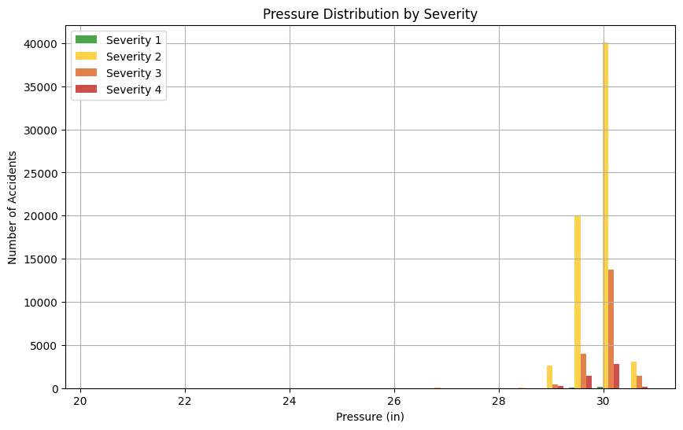

```python
# Combine data from all severity levels into one list
combined_data = [df["Pressure(in)"][df["Severity"] == i + 1] for i in range(4)]

# Define colors for each severity level
severity_colors = ["green", "#FFC000", "#d64c00", "#bb0402"]

# Create a single histogram with different colors
plt.figure(figsize=(10, 6))
plt.hist(combined_data, bins=20, color=severity_colors, alpha=0.7, label=['Severity 1', 'Severity 2', 'Severity 3', 'Severity 4'])
plt.title("Pressure Distribution by Severity")
plt.xlabel("Pressure (in)")
plt.ylabel("Number of Accidents")
plt.legend()
plt.grid(True)
plt.show()
```

Visually, it looks like the distribution skewed normal with a majority of the accidents at around 30 in. We are interested in whether the means of the distributions are actually significantly different from each other, so to get a more definitive view, we can apply an ANOVA test again. An ANOVA test is appropriate here since the distributions appear roughly normal and each sample should be mostly independent.

Thus, assuming an alpha value of 0.05,

Null hypothesis: There is no significant difference between the means of the distributions for each severity level.

Alternative hypothesis: There is a significant difference between the means of the distributions for each severity level.

```python
press_df = df[["Pressure(in)", "Severity"]].dropna()
press_sev_distributions = [press_df["Pressure(in)"][press_df["Severity"] == i + 1] for i in range(4)]
F, p = f_oneway(press_sev_distributions[0], press_sev_distributions[1], press_sev_distributions[2], press_sev_distributions[3])
p
```

```
6.964755220026016e-270
```

Since the obtained p-value is less than 0.05, we reject the null hypothesis and therefore conclude that there is a significant difference between the means of the distributions for each severity level of pressure.

Now that we have analysed the data and established the fact that there is a connectiom between Visibility severity, windchill - severity, humidity - severity, pressure - severity, and location - severity, we can use these as parameters to predict the severity of an accident. We have created a neural network that uses [linear layers](https://docs.nvidia.com/deeplearning/performance/dl-performance-fully-connected/index.html), [batch normalization layers](https://www.analyticsvidhya.com/blog/2021/03/introduction-to-batch-normalization/#:~:text=Now%20coming%20back%20to%20Batch,coming%20from%20a%20previous%20layer.), and dropout layers. Batch normalization layers normalize the activations of each layer across the mini-batch. It helps stabilize training by reducing internal covariate shift and can speed up convergence. The dropout layers drop the weights of the nodes at random and help prevent overfitting.

Over the course of creating this model, we tinkered with the number of linear layers, drop out layers, added batch normalization layers to make the network more complex (thereby have a batter accuracy in our case), changed epochs, changed learning rates, features used to to predict the target, and tinkered with similar aspects of the neural network. This was the best accuracy we got.

```python
# We import the necessary pyTorch modules. We also import sklearn modules to help prepare the
# data, like with splitting and scaling
from sklearn.preprocessing import StandardScaler, LabelEncoder
import torch
import torch.nn as nn
import torch.optim as optim
from torch.utils.data import DataLoader, TensorDataset

# Select relevant features and define our feature and target data
nn_df = df.dropna()
X_cols = ['Visibility(mi)', 'Start_Lat', 'End_Lat', "Wind_Chill(F)", "Humidity(%)", "Pressure(in)"]
y_col = 'Severity'
nn_df = nn_df[X_cols + [y_col]]

# Ensure our severity values are 1, 2, 3, or 4
nn_df[y_col] = np.clip(nn_df[y_col], 1, 4)

# Split the dataset into training and testing sets
X = nn_df[X_cols]
y = nn_df[y_col]
X_train, X_test, y_train, y_test = train_test_split(X, y, test_size=0.2, random_state=42)

# Standardize all features. They are all numeric.
scaler = StandardScaler()
X_train_scaled = scaler.fit_transform(X_train)
X_test_scaled = scaler.transform(X_test)

# Convert data to PyTorch tensors.
# Since ort severity values start from 1, we subtract 1 to map values to 0 based indexing.
# The severity rating is essentially a categorical data with 4 distinct possible ratings.
X_train_tensor = torch.tensor(X_train_scaled, dtype=torch.float32)
X_test_tensor = torch.tensor(X_test_scaled, dtype=torch.float32)
y_train_tensor = torch.tensor(y_train.values - 1, dtype=torch.long)
y_test_tensor = torch.tensor(y_test.values - 1, dtype=torch.long)

# We create a DataLoader to pass data into the neural network.
train_dataset = TensorDataset(X_train_tensor, y_train_tensor)
test_dataset = TensorDataset(X_test_tensor, y_test_tensor)
train_loader = DataLoader(train_dataset, batch_size=32, shuffle=True)
test_loader = DataLoader(test_dataset, batch_size=32, shuffle=False)

# Define the neural network model.
class NeuralNetwork(nn.Module):
    def __init__(self):
        super(NeuralNetwork, self).__init__()
        self.fc1 = nn.Linear(len(X_cols), 512)
        self.bn1 = nn.BatchNorm1d(512)
        self.fc2 = nn.Linear(512, 256)
        self.bn2 = nn.BatchNorm1d(256)
        self.fc3 = nn.Linear(256, 128)
        self.bn3 = nn.BatchNorm1d(128)
        self.fc4 = nn.Linear(128, 64)
        self.fc5 = nn.Linear(64, 4)  # Output layer with 4 classes (severity values 1, 2, 3, 4)
        self.dropout1 = nn.Dropout(0.4)
        self.dropout2 = nn.Dropout(0.125)
        self.dropout3 = nn.Dropout(0.3)
        self.dropout4 = nn.Dropout(0.02)

    def forward(self, x):
        x = torch.relu(self.bn1(self.fc1(x)))
        x = self.dropout1(x)
        x = torch.relu(self.bn2(self.fc2(x)))
        x = self.dropout2(x)
        x = torch.relu(self.bn3(self.fc3(x)))
        x = self.dropout3(x)
        x = self.fc4(x)
        x = self.dropout4(x)
        x = self.fc5(x)
        return x

# Initialize the model, loss function, and optimizer
model = NeuralNetwork()
criterion = nn.CrossEntropyLoss()
optimizer = optim.Adam(model.parameters(), lr=0.001)

# Initialize number of epochs to run and the loss value array to help visualize the learning of the model.
loss_values = []
num_epochs = 10

# Train the model
for epoch in range(num_epochs):
    running_loss = 0.0
    for inputs, labels in train_loader:
        optimizer.zero_grad()
        outputs = model(inputs)

        loss = criterion(outputs, labels)
        loss.backward()
        optimizer.step()
        running_loss += loss.item()

    # Print the epoch number and the loss for that epoch.
    print(f"Epoch [{epoch + 1}/{num_epochs}], Loss: {loss.item():.4f}")

    # Generating and appending the loss values for vizualization.
    epoch_loss = running_loss / len(train_loader)
    loss_values.append(epoch_loss)

# Evaluate the model
correct = 0
total = 0
with torch.no_grad():
    for inputs, labels in test_loader:
        outputs = model(inputs)
        # Get the predicted class with the highest probability
        _, predicted = torch.max(outputs, 1)
        total += labels.size(0)
        correct += (predicted == labels).sum().item()

# Print the accuracy of the model as observed on the testing data.
print(f"Test Accuracy: {correct / total}")
```

```
Epoch [1/10], Loss: 0.1373
Epoch [2/10], Loss: 0.3068
Epoch [3/10], Loss: 0.0750
Epoch [4/10], Loss: 0.1883
Epoch [5/10], Loss: 0.1297
Epoch [6/10], Loss: 0.1408
Epoch [7/10], Loss: 0.5606
Epoch [8/10], Loss: 0.2393
Epoch [9/10], Loss: 0.1801
Epoch [10/10], Loss: 0.1833
Test Accuracy: 0.941859059591442
```

Now let us visualize the training progress of the model.

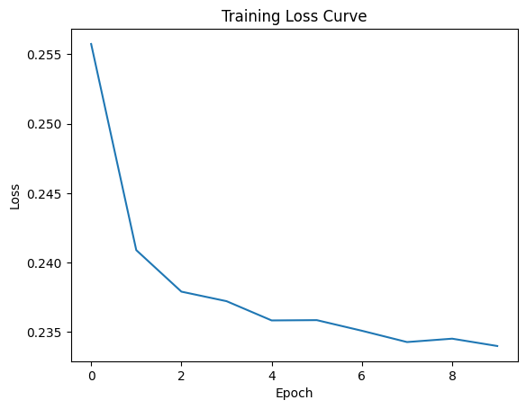

```python
plt.plot(range(num_epochs), loss_values)
plt.xlabel("Epoch")
plt.ylabel("Loss")
plt.title("Training Loss Curve")
plt.show()
```

Looking at the training loss curve, you can see the model getting better at it trains. With an accuracy of about 94%, the model is fairly accurate and reliable.

**Conclusion:**

Using accident data to predict severity can be incredibly useful in the real world. It can help revolutionize the measures taken by authorities for enhancing road safety by identifying high-risk areas or conditions where accidents of greater severity are more likely to occur. Additionally, predictive models can assist emergency response services in allocating resources efficiently by prioritizing high-severity accident prone areas, which could reduce response times and improve outcomes for those involved in accidents. Going forward, this prediction can assist with predicting the risk chances of a particular journey (given the path) or can notify a driver when they approch more accident prone areas. Albiet a brief reminder, this can create a huge impact in road safety. Overall, using accident data for severity prediction enables improved safety outcomes on the roads, leading to safer communities and reduced economic costs associated with road accidents.

```python
##for converting to html
%%shell
jupyter nbconvert --to html /content/CMSC320_Final_Project.ipynb
```